# 05_clustering_md_20201116

## 05. Non-parametric Unsupervised- Grid-Search Learning wit K-Means Algorithm

### 0. Settings

### 1. Table Meta info.

### 2. STR Tables

```python
file_dir = save_dir + 'STR 기초 데이터_v0.1.xlsx'

# List of DataFrame
# table_list = [TB_MAT_0100M,TB_MAT_0210M,TB_MAT_0300M,TB_MAT_0330M,TB_MAT_0340M,TB_MAT_0430M,TB_MAT_0511M,TB_MAT_0512M,TB_MAT_0513M]
table_list = []

# Read & insertion
for i, tab_name in enumerate(table_meta_['TABLE'].unique()):
    # get col dtype info DataFrame
    col_dtype_ = table_meta_.loc[table_meta_['TABLE'].eq(tab_name),['COL', 'DTYPE_PY']]
    # Dictionary for {column_name: column_dtype}
    dtype_dict = {row[1]: row[2] for row in col_dtype_.itertuples()}
    # read table
    # table_list[i] = pd.read_excel(file_dir, skiprows=[1], header=0, sheet_name=tab_name, dtype=dtype_dict)
    tmp_df = pd.read_excel(file_dir, skiprows=[1], header=0, sheet_name=tab_name, dtype=dtype_dict)
    tmp_df.name = tab_name
    table_list.append(tmp_df)

# table_list
```

```python
# table_list[0]

TB_MAT_0100M = table_list[0]
TB_MAT_0210M = table_list[1]
TB_MAT_0300M = table_list[2]
TB_MAT_0330M = table_list[3]
TB_MAT_0340M = table_list[4]
TB_MAT_0430M = table_list[5]
TB_MAT_0511M = table_list[6]
TB_MAT_0512M = table_list[7]
TB_MAT_0513M = table_list[8]
```

### 3. Export STR Tables

```python
# modularize
# table_meta_
```

```python
# convert table
cust_data = TB_MAT_0100M
loan_data = TB_MAT_0210M
ins_data = TB_MAT_0300M
give_data = TB_MAT_0330M
repay_data = TB_MAT_0340M
over_data = TB_MAT_0430M
prod_data = TB_MAT_0511M
job_data = TB_MAT_0512M
biz_data = TB_MAT_0513M
```

### 4. STR Dataset: CUST_DATA

#### * Generate Numeric features for Non-parametric-unsupervised approach

*: **비지도 알고리즘 적용** 을 위해 *수치형 변수 및 수치형 파생변수가 필요*

*: **고객개인정보 가운데, 고유성을 가져야 하는 정보** 에 대한 산발적 발생 및 의심사례에 대한 **수치형 파생변수화** 적용*

#### * Numeric Dataset

```python
cust_set
```

| CUST_NO | HpstCNT | HtelCNT | ProfCNT | PtelCNT |
| --- | --- | --- | --- | --- |
| 1800397 | 1.0 | 0.0 | 1.0 | 1 |
| 1797304 | 0.0 | 0.0 | 1.0 | 1 |
| 1789073 | 0.0 | 0.0 | 1.0 | 1 |
| 1798529 | 0.0 | 0.0 | 1.0 | 1 |
| 1798711 | 0.0 | 0.0 | 1.0 | 5 |
| ... | ... | ... | ... | ... |
| 1534874 | 1.0 | 1.0 | 1.0 | 1 |
| 1341488 | 1.0 | 0.0 | 83.0 | 1 |
| 1369380 | 1.0 | 0.0 | 1.0 | 1 |
| 1389734 | 1.0 | 0.0 | 0.0 | 1 |
| 1451844 | 0.0 | 0.0 | 0.0 | 1 |

720 rows × 4 columns

```python
cust_set.describe()
```

|  | HpstCNT | HtelCNT | ProfCNT | PtelCNT |
| --- | --- | --- | --- | --- |
| count | 720.000000 | 720.000000 | 720.000000 | 720.000000 |
| mean | 1.002778 | 0.700000 | 10.352778 | 1.052778 |
| std | 2.331974 | 2.854175 | 26.313674 | 0.418612 |
| min | 0.000000 | 0.000000 | 0.000000 | 1.000000 |
| 25% | 0.000000 | 0.000000 | 0.000000 | 1.000000 |
| 50% | 1.000000 | 0.000000 | 1.000000 | 1.000000 |
| 75% | 1.000000 | 0.000000 | 1.000000 | 1.000000 |
| max | 16.000000 | 15.000000 | 83.000000 | 5.000000 |

### Fit Unsupervised-Learning Algorithms

#### *: Check Linearly indepent with Correlation Matrix*

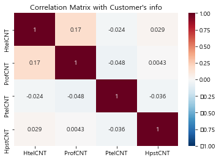

*: **Validity of Linear-indepent** condition precedes all other approaches for **Data Wrangling, Learning-algorithm Fitting**.*

### 1. K-Means Clustering

#### * K-Means with Initial K=3

```python
cust_x['cluster'].value_counts()
```

```
1    619
0     83
2     18
Name: cluster, dtype: int64
```

### Visualization with PCA

```python
cust_x['pca_x'] = pca_transf[:,0]
cust_x['pca_y'] = pca_transf[:,1]

print("   ::: Dimension Reduction with two-Principle Components :::   ")
cust_x.head(3)
```

```
   ::: Dimension Reduction with two-Principle Components :::
```

| CUST_NO | HtelCNT | ProfCNT | PtelCNT | HpstCNT | cluster | pca_x | pca_y |
| --- | --- | --- | --- | --- | --- | --- | --- |
| 1800397 | 0.0 | 1.0 | 1 | 1.0 | 1 | -9.364842 | -0.519358 |
| 1797304 | 0.0 | 1.0 | 1 | 0.0 | 1 | -9.365231 | -0.595129 |
| 1789073 | 0.0 | 1.0 | 1 | 0.0 | 1 | -9.365231 | -0.595129 |

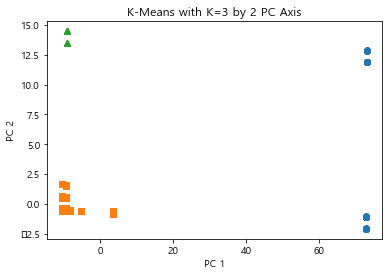

```python
plt.xlabel('PC 1')
plt.ylabel('PC 2')
plt.title('K-Means with K=3 by 2 PC Axis')
plt.show()
```

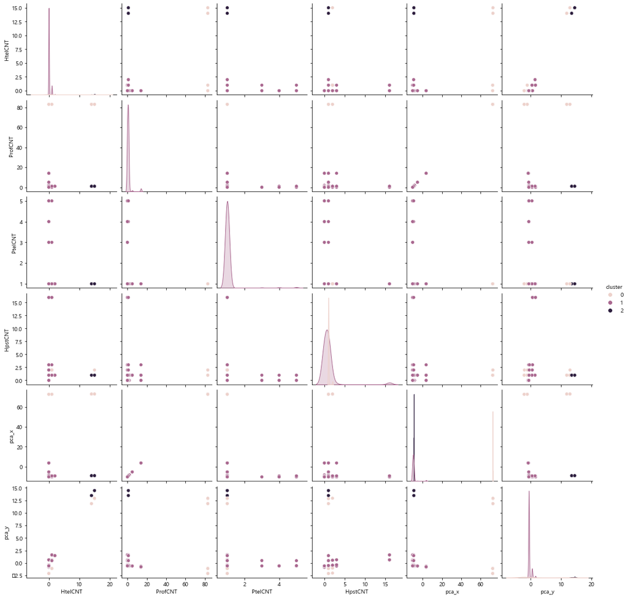

```python
import seaborn as sns
sns.pairplot(cust_x, hue="cluster")
```

*: **PCA** 는 주어진 데이터에 대해, Infomation Loss를 최소화 하는 **Feature Engineering-Dimension Reduction** 수행 방법.*  
*: **Feature Engineering with PCA** 를 통해, **Clustering fitting 결과를 기하적 접근** 에서 탐색 수행*

### * Normalization with Scalers

#### * Original Set

```python
origin_cols_ = cust_set.columns
cust_set.head(7)
```

| CUST_NO | HtelCNT | ProfCNT | PtelCNT | HpstCNT |
| --- | --- | --- | --- | --- |
| 1800397 | 0.0 | 1.0 | 1 | 1.0 |
| 1797304 | 0.0 | 1.0 | 1 | 0.0 |
| 1789073 | 0.0 | 1.0 | 1 | 0.0 |
| 1798529 | 0.0 | 1.0 | 1 | 0.0 |
| 1798711 | 0.0 | 1.0 | 5 | 0.0 |
| 1772198 | 0.0 | 1.0 | 1 | 0.0 |
| 1788256 | 0.0 | 0.0 | 3 | 0.0 |

#### * with StandardScaler

```python
cust_set_stnd.head(7)
```

|  | HtelCNT | ProfCNT | PtelCNT | HpstCNT |
| --- | --- | --- | --- | --- |
| 0 | -0.245425 | -0.355681 | -0.126166 | -0.001192 |
| 1 | -0.245425 | -0.355681 | -0.126166 | -0.430311 |
| 2 | -0.245425 | -0.355681 | -0.126166 | -0.430311 |
| 3 | -0.245425 | -0.355681 | -0.126166 | -0.430311 |
| 4 | -0.245425 | -0.355681 | 9.435874 | -0.430311 |
| 5 | -0.245425 | -0.355681 | -0.126166 | -0.430311 |
| 6 | -0.245425 | -0.393711 | 4.654854 | -0.430311 |

```python
cust_set_stnd.describe()
```

|  | HtelCNT | ProfCNT | PtelCNT | HpstCNT |
| --- | --- | --- | --- | --- |
| count | 7.200000e+02 | 720.000000 | 7.200000e+02 | 7.200000e+02 |
| mean | -9.868649e-18 | 0.000000 | -1.270589e-16 | -9.868649e-18 |
| std | 1.000695e+00 | 1.000695 | 1.000695e+00 | 1.000695e+00 |
| min | -2.454253e-01 | -0.393711 | -1.261658e-01 | -4.303114e-01 |
| 25% | -2.454253e-01 | -0.393711 | -1.261658e-01 | -4.303114e-01 |
| 50% | -2.454253e-01 | -0.355681 | -1.261658e-01 | -1.191998e-03 |
| 75% | -2.454253e-01 | -0.355681 | -1.261658e-01 | -1.191998e-03 |
| max | 5.013687e+00 | 2.762736 | 9.435874e+00 | 6.435599e+00 |

#### * with MinMaxScaler

```python
cust_set_MnMx.head(7)
```

|  | HtelCNT | ProfCNT | PtelCNT | HpstCNT |
| --- | --- | --- | --- | --- |
| 0 | 0.0 | 0.012048 | 0.0 | 0.0625 |
| 1 | 0.0 | 0.012048 | 0.0 | 0.0000 |
| 2 | 0.0 | 0.012048 | 0.0 | 0.0000 |
| 3 | 0.0 | 0.012048 | 0.0 | 0.0000 |
| 4 | 0.0 | 0.012048 | 1.0 | 0.0000 |
| 5 | 0.0 | 0.012048 | 0.0 | 0.0000 |
| 6 | 0.0 | 0.000000 | 0.5 | 0.0000 |

```python
cust_set_MnMx.describe()
```

|  | HtelCNT | ProfCNT | PtelCNT | HpstCNT |
| --- | --- | --- | --- | --- |
| count | 720.000000 | 720.000000 | 720.000000 | 720.000000 |
| mean | 0.046667 | 0.124732 | 0.013194 | 0.062674 |
| std | 0.190278 | 0.317032 | 0.104653 | 0.145748 |
| min | 0.000000 | 0.000000 | 0.000000 | 0.000000 |
| 25% | 0.000000 | 0.000000 | 0.000000 | 0.000000 |
| 50% | 0.000000 | 0.012048 | 0.000000 | 0.062500 |
| 75% | 0.000000 | 0.012048 | 0.000000 | 0.062500 |
| max | 1.000000 | 1.000000 | 1.000000 | 1.000000 |

*: Since derivates in dataset are highly "Skewed", also not to be normal density,*  
*. **using MinMaxScaler** as a Hypothesis*  
*: 데이터셋 안에 *파생 수치형 변수들은 고도로 '치우쳐'져있도록 설계되었고, 정규분포 가정을 따르지도 않으므로,*  
*. **MinMaxScaler를 사용** 함을 가정으로 한다.*

#### * K-Means with Initial K=3

```python
cust_set_MnMx['cluster'].value_counts()
```

```
0    619
1     83
2     18
Name: cluster, dtype: int64
```

### * Visualization with PCA

```python
cust_set_MnMx['pca_x'] = pca_transf[:,0]
cust_set_MnMx['pca_y'] = pca_transf[:,1]
cust_set_MnMx.head(3)
```

|  | HtelCNT | ProfCNT | PtelCNT | HpstCNT | cluster | pca_x | pca_y |
| --- | --- | --- | --- | --- | --- | --- | --- |
| 0 | 0.0 | 0.012048 | 0.0 | 0.0625 | 0 | -0.204982 | 0.009285 |
| 1 | 0.0 | 0.012048 | 0.0 | 0.0000 | 0 | -0.205109 | 0.008598 |
| 2 | 0.0 | 0.012048 | 0.0 | 0.0000 | 0 | -0.205109 | 0.008598 |

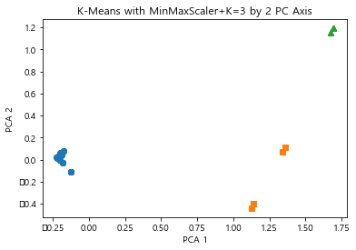

```python
plt.xlabel('PCA 1')
plt.ylabel('PCA 2')
plt.title('K-Means with MinMaxScaler+K=3 by 2 PC Axis')
plt.show()
```

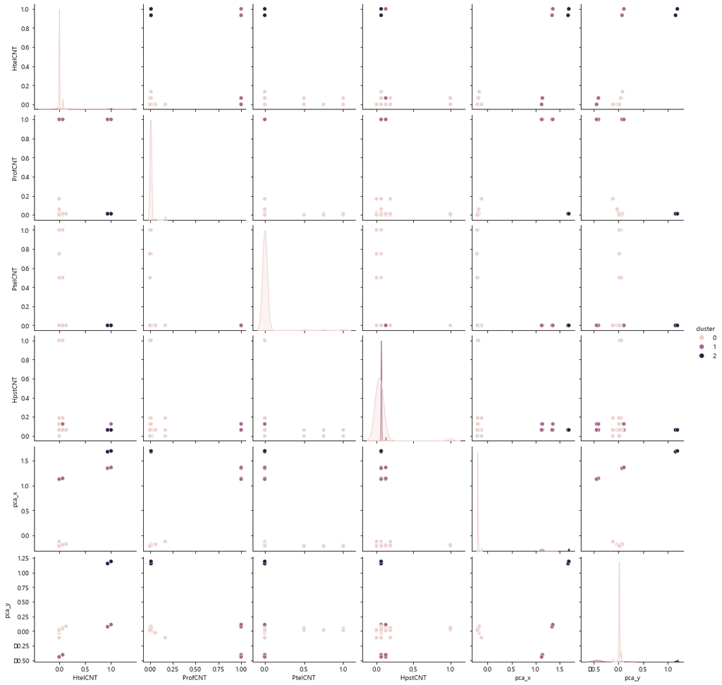

```python
import seaborn as sns

sns.pairplot(cust_set_MnMx, hue="cluster")
```

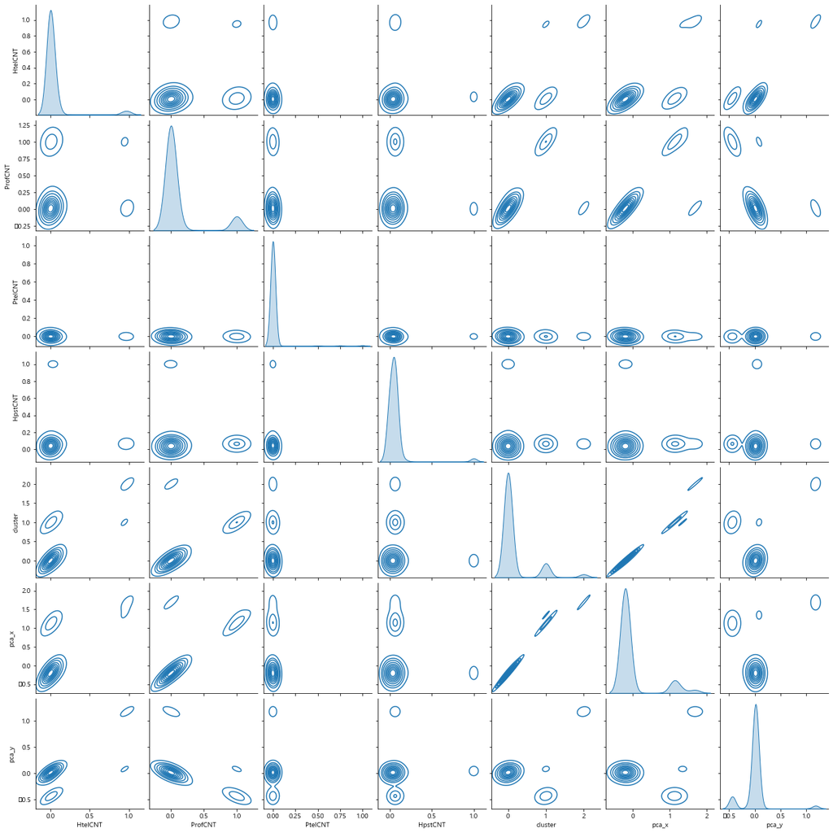

```python
sns.pairplot(cust_set_MnMx, kind='kde')
```

*: 변수 간 Correlation distribution을 통해, 군집 별 데이터 밀집 경향을 파악*

#### *: **다차원(Multi-dimensional)내 각각의 초-공간마다** -*

> 1. **군집 간, 다극(Multipolarized)화** 되어 있을 수록,(= 군집 간 더 멀리 떨어져 있을 수록)
> 2. **군집 내, 중심을 기준으로 고밀도**를 가질 수록, (=highly densed, centralized)

*비지도 학습이 보다 더 잘 이루어진 것을 파악할 수 있음*

```python
cust_set_MnMx.iloc[:,0:4]
```

|  | HtelCNT | ProfCNT | PtelCNT | HpstCNT |
| --- | --- | --- | --- | --- |
| 0 | 0.000000 | 0.012048 | 0.0 | 0.0625 |
| 1 | 0.000000 | 0.012048 | 0.0 | 0.0000 |
| 2 | 0.000000 | 0.012048 | 0.0 | 0.0000 |
| 3 | 0.000000 | 0.012048 | 0.0 | 0.0000 |
| 4 | 0.000000 | 0.012048 | 1.0 | 0.0000 |
| ... | ... | ... | ... | ... |
| 715 | 0.066667 | 0.012048 | 0.0 | 0.0625 |
| 716 | 0.000000 | 1.000000 | 0.0 | 0.0625 |
| 717 | 0.000000 | 0.012048 | 0.0 | 0.0625 |
| 718 | 0.000000 | 0.000000 | 0.0 | 0.0625 |
| 719 | 0.000000 | 0.000000 | 0.0 | 0.0000 |

720 rows × 4 columns

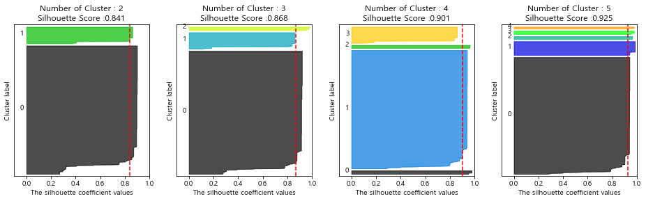

```python
GridSearch_silhouette([ 2, 3, 4, 5], cust_set_MnMx.iloc[:,0:4])
```

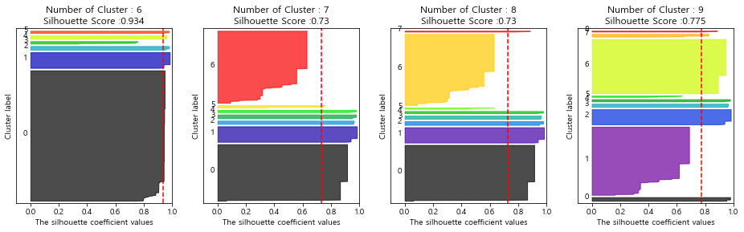

```python
GridSearch_silhouette([6, 7, 8, 9], cust_set_MnMx.iloc[:,0:4])
```

*: 비지도 학습에 대한 정량적 평가 지표 (Clustering Evaluation)적용*  
*: **실루엣 스코어(Silhouette score)* 참조**.*

```python
frames = [k4_clst_cnt, k5_clst_cnt, k6_clst_cnt]
GS_clst_df = pd.concat(frames, axis=1).fillna(0)
GS_clst_df.index = ['cluster_0', 'cluster_1', 'cluster_2', 'cluster_3', 'cluster_4', 'cluster_5']
GS_clst_df
```

|  | KMeans_4 | KMeans_5 | KMeans_6 |
| --- | --- | --- | --- |
| cluster_0 | 603.0 | 603.0 | 591 |
| cluster_1 | 83.0 | 72.0 | 72 |
| cluster_2 | 18.0 | 18.0 | 18 |
| cluster_3 | 16.0 | 16.0 | 16 |
| cluster_4 | 0.0 | 11.0 | 12 |
| cluster_5 | 0.0 | 0.0 | 11 |

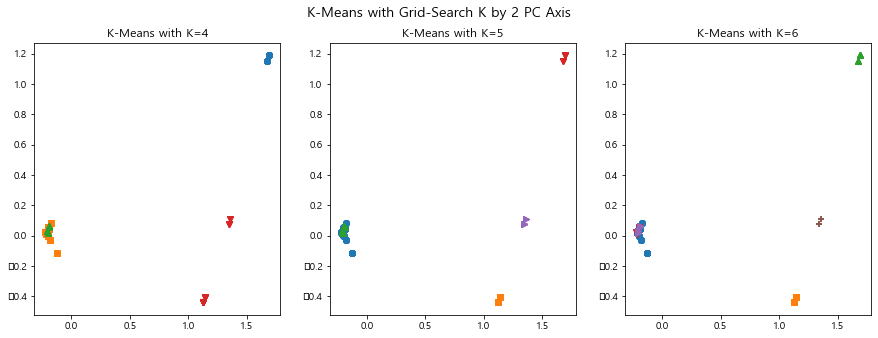

```python
n_cols = 3

fig.suptitle('K-Means with Grid-Search K by 2 PC Axis',  fontsize=14)
axs[0].set_title('K-Means with K=4')
axs[1].set_title('K-Means with K=5')
axs[2].set_title('K-Means with K=6')
```

*: 위 **실루엣 스코어를 기준으로, 높은 스코어와 군집 간 균일도가 높은 k=4, 5, 6에 대한, 비지도 군집분석 결과 시각화**에 해당*  
*: **K=넘버가 올라 갈 수록 보다 세분화된 이상치를 구분** 이 가능한 모습을 보이지만,*  
*: 그 수가 높아질 수록, **군집에 대한 과적합(overfitting)이 심해지는 경향** 역시 관찰 가능*

### * Visualization with PCA

```python
cust_x_5
```

|  | HtelCNT | ProfCNT | PtelCNT | HpstCNT | cluster | pca_x | pca_y |
| --- | --- | --- | --- | --- | --- | --- | --- |
| 0 | 0.000000 | 0.012048 | 0.0 | 0.0625 | 0 | -0.204982 | 0.009285 |
| 1 | 0.000000 | 0.012048 | 0.0 | 0.0000 | 0 | -0.205109 | 0.008598 |
| 2 | 0.000000 | 0.012048 | 0.0 | 0.0000 | 0 | -0.205109 | 0.008598 |
| 3 | 0.000000 | 0.012048 | 0.0 | 0.0000 | 0 | -0.205109 | 0.008598 |
| 4 | 0.000000 | 0.012048 | 1.0 | 0.0000 | 0 | -0.215957 | 0.014822 |
| ... | ... | ... | ... | ... | ... | ... | ... |
| 715 | 0.066667 | 0.012048 | 0.0 | 0.0625 | 0 | -0.189384 | 0.045997 |
| 716 | 0.000000 | 1.000000 | 0.0 | 0.0625 | 1 | 1.124656 | -0.439546 |
| 717 | 0.000000 | 0.012048 | 0.0 | 0.0625 | 0 | -0.204982 | 0.009285 |
| 718 | 0.000000 | 0.000000 | 0.0 | 0.0625 | 0 | -0.211066 | 0.018598 |
| 719 | 0.000000 | 0.000000 | 0.0 | 0.0000 | 0 | -0.211193 | 0.017911 |

720 rows × 7 columns

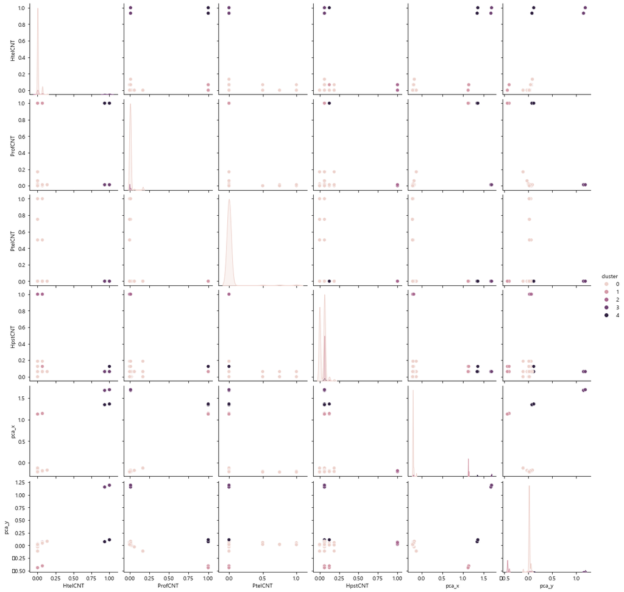

```python
import seaborn as sns

sns.pairplot(cust_x_5, hue="cluster")
```

*: k=5에 해당하는 세부군집마다 변수 내 분할 정도를 파악*

```python
cust_x_5
```

|  | HtelCNT | ProfCNT | PtelCNT | HpstCNT | cluster | pca_x | pca_y |
| --- | --- | --- | --- | --- | --- | --- | --- |
| 0 | 0.000000 | 0.012048 | 0.0 | 0.0625 | 0 | -0.204982 | 0.009285 |
| 1 | 0.000000 | 0.012048 | 0.0 | 0.0000 | 0 | -0.205109 | 0.008598 |
| 2 | 0.000000 | 0.012048 | 0.0 | 0.0000 | 0 | -0.205109 | 0.008598 |
| 3 | 0.000000 | 0.012048 | 0.0 | 0.0000 | 0 | -0.205109 | 0.008598 |
| 4 | 0.000000 | 0.012048 | 1.0 | 0.0000 | 0 | -0.215957 | 0.014822 |
| ... | ... | ... | ... | ... | ... | ... | ... |
| 715 | 0.066667 | 0.012048 | 0.0 | 0.0625 | 0 | -0.189384 | 0.045997 |
| 716 | 0.000000 | 1.000000 | 0.0 | 0.0625 | 1 | 1.124656 | -0.439546 |
| 717 | 0.000000 | 0.012048 | 0.0 | 0.0625 | 0 | -0.204982 | 0.009285 |
| 718 | 0.000000 | 0.000000 | 0.0 | 0.0625 | 0 | -0.211066 | 0.018598 |
| 719 | 0.000000 | 0.000000 | 0.0 | 0.0000 | 0 | -0.211193 | 0.017911 |

720 rows × 7 columns

```python
cust_x_5['cluster'].value_counts()
```

```
0    603
1     72
3     18
2     16
4     11
Name: cluster, dtype: int64
```

### 5. Cross-Search with LOAN_DATA Table

```python
# cust_data

frames = [cust_data['CUST_NO'], cust_x_5['cluster']]

cust_clst5 = pd.concat(frames, axis=1)
cust_clst5
```

|  | CUST_NO | cluster |
| --- | --- | --- |
| 0 | 1800397 | 0 |
| 1 | 1797304 | 0 |
| 2 | 1789073 | 0 |
| 3 | 1798529 | 0 |
| 4 | 1798711 | 0 |
| ... | ... | ... |
| 715 | 1534874 | 0 |
| 716 | 1341488 | 1 |
| 717 | 1369380 | 0 |
| 718 | 1389734 | 0 |
| 719 | 1451844 | 0 |

720 rows × 2 columns

```python
loan_clst5.head(7)
```

```
 >>> loan_data.shape       : (2659, 36)
 >>> after_InnerJoin.shape : (1199, 37)
```

|  | FNOGYE | CUST_NO | LOAN_NO | TRANS_DT | FJMCHI | FLGWACD | FMGWACD | FGWACD | FGBUPM | PROD_CD | CHNL_CD | FILSIN | FILMAN | OVER_NT | OVER_STDT | GYE_YN | BANK_CODE | SANG_GYENO | SANG_CUST | SANG_ACCNT_REL | SANG_TRANS | CON_AMT | FGMJAN | WRNT_AMT | NAP_TYPE | LS_GOODS | SUCC_CUST | SUCC_GU | SUCC_DT | … |
| --- | --- | --- | --- | --- | --- | --- | --- | --- | --- | --- | --- | --- | --- | --- | --- | --- | --- | --- | --- | --- | --- | --- | --- | --- | --- | --- | --- | --- | --- | --- |
| 0 | 219LO058672 | 1009100 | 219LO058672-0001 | 20190801 | 000320 | I02LO | E09113 | LO098708 | 20 | I02LOE09113LO098708 | B | 20190801 | 20191215 | N | NaN | 01 | C07003 | 41887864460563 | 1009100 | Y | 103 | 130000000.0 | 130000000.0 | NaN | NaN | NaN | NaN | NaN | NaN | … |
| 1 | 219IF022909 | 1043337 | 219IF022909-0001 | 20190812 | 000371 | I02IF | E0620 | IF063059 | 21 | I02IFE0620IF063059 | B | 20190812 | 20200525 | N | NaN | 01 | C07003 | 78181467260505 | 1043337 | Y | 102 | 10000000.0 | 10000000.0 | NaN | NaN | NaN | NaN | NaN | NaN | … |
| 2 | 219LO062571 | 1049976 | 219LO062571-0001 | 20190812 | 000140 | I02LO | E0971 | NaN | 20 | I02LOE0971 | T | 20190812 | 20240801 | N | NaN | 01 | C07032 | 187318346184 | 1049976 | Y | 102 | 7500000.0 | 7500000.0 | NaN | NaN | NaN | NaN | NaN | NaN | … |
| 3 | 219IF022842 | 1054477 | 219IF022842-0001 | 20190812 | 000371 | I02IF | E0620 | IF063059 | 21 | I02IFE0620IF063059 | B | 20190812 | 20200720 | N | NaN | 01 | C07081 | 54651915578243 | 1054477 | Y | 102 | 10000000.0 | 10000000.0 | NaN | NaN | NaN | NaN | NaN | NaN | … |
| 4 | 215AL015544 | 1085857 | 215AL015544-0002 | 20190812 | 000580 | I02AL | E0301 | ATR01 | 10 | I02ALE0301ATR01 | B | 20190812 | 20200805 | N | NaN | 01 | C07003 | 63883388967504 | 1085857 | Y | 102 | 10044000.0 | 10044000.0 | NaN | NaN | NaN | NaN | NaN | NaN | … |
| 5 | 219LO061877 | 1143077 | 219LO061877-0001 | 20190808 | 000140 | I02LO | E09043 | NaN | 23 | I02LOE09043 | T | 20190808 | 20210810 | N | NaN | 01 | C07011 | 4118840166798 | 1143077 | Y | 102 | 10000000.0 | 10000000.0 | NaN | NaN | NaN | NaN | NaN | NaN | … |
| 6 | 219LO062751 | 1143717 | 219LO062751-0001 | 20190813 | 000580 | I02LO | E0954 | BHHK62 | 20 | I02LOE0954BHHK62 | A | 20190813 | 20220805 | N | NaN | 01 | C07011 | 57813352667 | 1143717 | Y | 102 | 13000000.0 | 13000000.0 | NaN | NaN | NaN | NaN | NaN | NaN | … |

_: 고객정보로 걸러진 **여신원장 테이블 'LOAN_NO'수 : 2,659개 중 1,199개**._

```python
# feature exploration

# ----------------------
# set current working df
curr_df = loan_clst5.copy()
# curr_df.head()
# ----------------------
idx_x = ['LOAN_NO', 'label', 'y']
val_x_mask = ~curr_df.columns.isin(idx_x)

# 0. Total value_counts for current df
nuniq_ = curr_df.nunique()

# 1. find empty-features
zero_x = nuniq_[nuniq_.eq(0)&val_x_mask]

# 2. find only-one-value features
only_x = nuniq_[nuniq_.eq(1)&val_x_mask]

# 3. set categorical X-features for EDA
cat_x = nuniq_[nuniq_.gt(1)&nuniq_.lt(10)&val_x_mask]

# 4. e.t.c)
used_mask = set(zero_x.index)|set(only_x.index)|set(cat_x.index)|set(idx_x)
etc_col = list(set(nuniq_.index) - used_mask)
title_now = " X-etc. "
```

```
   =======     Empty X-features  (:discardable)     =======
['OVER_STDT', 'WRNT_AMT', 'NAP_TYPE', 'LS_GOODS', 'SUCC_CUST', 'SUCC_GU', 'SUCC_DT', 'SUCC_AMT']

   =======        only-one-value X-features         =======
['OVER_NT', 'OVER_CNT', 'PROCS_DT', 'PROCS_TM']

   =======      Categorical X-features for EDA      =======
['FLGWACD', 'FGBUPM', 'CHNL_CD', 'GYE_YN', 'SANG_ACCNT_REL', 'SANG_TRANS', 'FINAL_DT', 'cluster']
   =======   Categorical Xs' # of distinct values   =======
FLGWACD        : 7 Distinct values   >>> [ I02LO, I02IF, I02AL, I02GL, I02LC, I02NI, I02FR ]
FGBUPM         : 6 Distinct values   >>> [ 20, 21, 10, 23, 26, 25, nan ]
CHNL_CD        : 4 Distinct values   >>> [ B, T, A, I ]
GYE_YN         : 2 Distinct values   >>> [ 01, 03 ]
SANG_ACCNT_REL : 2 Distinct values   >>> [ Y, N ]
SANG_TRANS     : 2 Distinct values   >>> [ 103, 102 ]
FINAL_DT       : 7 Distinct values   >>> [ nan, 20190808, 20190812, 20190809, 20190813, 20190806, 20190805, 20190807 ]
cluster        : 5 Distinct values   >>> [ 0, 1, 2, 3, 4 ]

   =======                  X-etc.                  =======
PROCS_EMPNO      86
FJMCHI           40
TRANS_DT         11
FMGWACD          59
FILSIN           11
SANG_NO         692
FGMJAN          515
SANG_GYENO      714
FILMAN           89
PROD_CD         107
BANK_CODE        21
SANG_CUST       711
FGWACD           78
CUST_NO         720
CON_AMT         519
FNOGYE         1036
dtype: int64
```

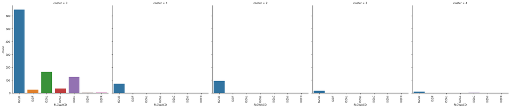

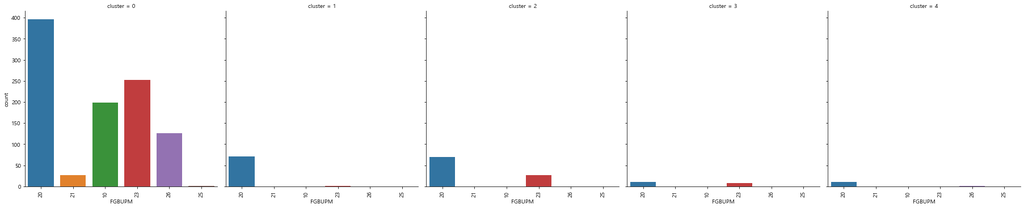

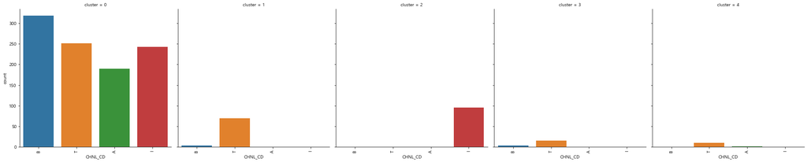

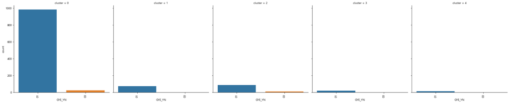

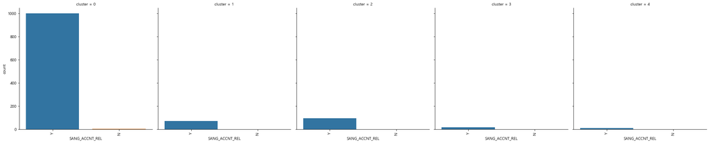

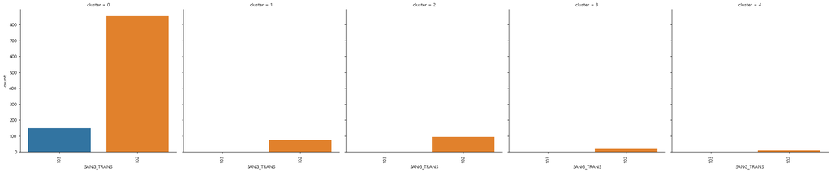

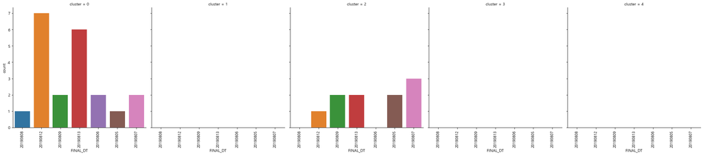

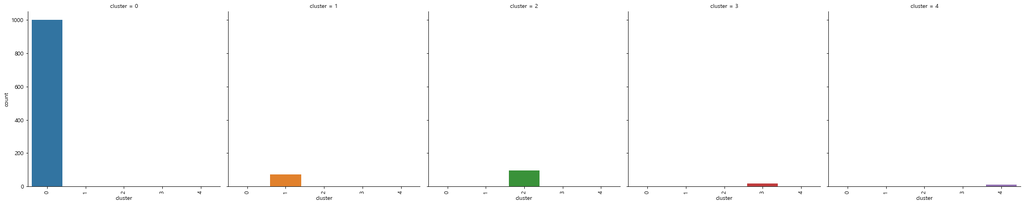

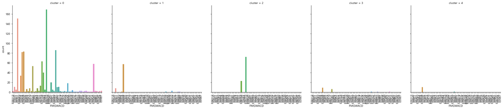

```python
iter_cols = cat_x.index.tolist()
iter_cols.append('FMGWACD')

for cat_col_ in iter_cols:
    g = sns.catplot(x=cat_col_, col='cluster', data=curr_df, kind='count')
    g.set_xticklabels(rotation=90)
```

*: '고객정보'기반 비지도 학습의 결과로 5개의 Cluster 추출 수행.*

> _. >>> **고객별 Tagging된 Cluster_ID별, LOAN_DATA 변수내 특이사항 빈도 분석** 수행 . >>> **군집 간 category dispersion이 Cluster=0을 대체로 따르는 경우, "군집 간 Trend 차이"를 찾기가 어려운 변수**에 해당. . >>> **군집 간 category dispersion이 대세와 상이한 경우, ex: 'CHNL_CD', 'FMGWACD'**. . >>> >>> **"군집 간, 다른 경향을 보인다"고 볼 수 있음**._

#### ex 1. 'CHNL_CD'

> Cluster0에 대해, channel='B'가 가장 높으나,  
> Cluster1에서는, channel='T'가 거의 단독으로 이용된 것을 볼 수 있고,  
> Cluster2에서는, channel='I'가 거의 단독으로 이용된 것을 볼 수 있음.  
> : 이를 근거로, 번호 및 주소등의 개인정보에 의한 비지도 분류를 통해, 여신 사용채널 접근 용이도 또는, 여신 수행 장벽 등의 패턴이 포착됨.

#### ex 2. 'FMGWACD'

> Cluster0에서는, 다 품목에 대해 여러 빈도를 보이는 분포가 -  
> Cluster1에서는, ('E0971')에 쏠리는 경향을 보이고,  
> Cluster2에서는, ('E09153','E09154', 특히 'E09153')에 전체가 몰린 경향을 볼 수 있다.  
> : 이를 근거로, 번호 및 주소등의 개인정보에 의한 비지도 분류를 통해, 여신 사용채널 접근 용이도 또는, 여신 수행 장벽 등의 패턴이 포착됨.

## 6. Summary

: 비지도 학습은 **빅데이터가 가진 다차원-역동적(Multi-dimensional, dynamic)성질** 에 따른, **Volume, Veracity, Variety** 등이 확보될수록  
그 안에 숨겨진 패턴과 새로운 Key-Feature를 발견할 수 있음.